# Presentation for Capstone Project

Bernard Fraenkel  
1/22/2016

Swiftkey Application

### Model and Results

- Most of the complexity of the model is in analyzing the corpus of text to generate the statiscal model - more specifically in data shaping, i.e. defining what a word is
  - Handling punctuation and abbreviations: e.g. “I'm”, “my friend's”
  - Filtering out words not in dictionary, and foul language
  - Determining which “stop words” to eliminate
- The preprocessing has the following steps:
  - Clean out each corpus based on the rules defined above
  - Using the cleaned-out corpus, compile probably distribution of single words, word pairs and word triplets
    - At each stage, the output is culled to keep only tokens that appear at least N times in the whole corpus (N = 10, 2, 1 respectively)
  - Based on the probability distribution of word pairs or triplets, determine the most likely next word for each word, or word-pair
  - Save this model for the predictor app
- The Predictor is relatively simple in comparison to the model generation
  - Pre-process the sentence
    - Alphabetic only & lowercase
    - Remove bad words, stop words and words not in dictionary
  - Prediction using Markov model with backoff

### Using the App

- The app can be found here: https://bfcorsair.shinyapps.io/Shiny/
- User enters a sentence - any number of words - in the left hand pane
- When user clicks the “Predict Next Word” button, the sentence - completed with the “next” word appears in the right hand pane, as predicted by the model
- Once the first prediction has been made, the app continues to predict as the user continues typing in the input box in left-hand pane

### Challenging Code

Computing the relative frequency of tokens (single or multiple words) reprensented a challenge due to the volume of the corpora and the limited amount of memory and CPU available on a laptop. We implemented a “Map-Reduce-like” approach where:

- Tokens are built from the corpus and appended to a large vector (Map)
- Once the vector is large enough, we tally the number of occurrences for each token
  - We use sort, then use run-length-encode (RLE) to count the number of occurences of each token within the vector
  - We then identify the tokens not seen in previous iterations and add them to a hash-table
  - We hash each token and use its hash as an index to a vector keeping the aggregate count
  - We use the package doParallel for faster processing

```r
tokenRLE <- rle(sort(tokenSet)) # Sort prior to run-length encode
# Identify the tokens in this batch which are not in the hash table
theseToken <- tokenRLE$values  # unique by construction
# newTokens are the members of theseToken whose key does not exist
newToken <- theseToken[sapply(theseToken, function(w){! has.key(w,tokenHash)})]
nbHash <- length(hashTbl)
nbNew <- length(newToken)
if (nbNew >0 ) { # add the new tokens to the hash table
    hashTbl[newToken] <- (nbHash+1):(nbHash+nbNew)
    # and to the list of tokens
    tknVct <- c(tknVct, newToken)
    # Initialize their count to 0
    tknCnt <- c(tknCnt, seq(0,0, length.out=nbNew))
}
# Add the respective counts - Use doParallel for parallel processing
foreach (i = 1:length(tokenRLE$values)) %dopar% {
    token <- tokenRLE$values[i]
    count <- tokenRLE$lengths[i]
    tknCnt[hashTbl[[token]]] <- tknCnt[hashTbl[[token]]] + count
}
```

### Token Frequency Distribution

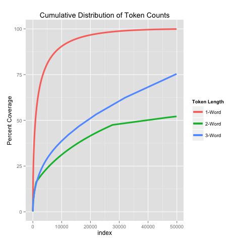